# Mn and nuerotoxicity

George W Kagugube

2025-05-01

## R Markdown

1. **Effects of Mn Exposure**
   - The effects of Mn related transcriptional changes were analysed when exposed WT were compared with Unexposed
2. **Effects of genotype**.
   - Mut control vs WT

Data up to this point has been generated using STAR with the latest reference genome.

```r
## Read the mapped and quantified files into r for further analysis here
file1 <- "1_S1_ReadsPerGene.out.tab"
dr <- '/Users/gwk/Desktop/PhD/Data/PhD_data/Brain/GZ11_star_output/star'

## load the data into R for further analysis here
# This is output from star - these are files with ReadsPerGene.out.tab
countMatrix <- staroutput_preprocessing(dr, file1)

samples <- read.csv("sample_information.csv", row.names = 1)
```

```r
## Explore the loaded data here
print(head(countMatrix[,1:6]))
```

```
##         1_S1_ 10_S10_ 13_S13_ 14_S14_ 17_S17_ 18_S18_
## rpl24    9689    6399    9962   10377   11260    9000
## cep97     110     111     122     124     166     112
## nfkbiz    110     120     146     129      83      95
## eed       169     167     206     210     235     174
## hikeshi   183     121     196     190     227     168
## tmem39a    87      72      77     140      94      91
```

```r
print(head(samples))
```

```
##         sampleID Genotype Treatment         Group  batch
## 1   wt_unexposed       wt unexposed  wt_unexposed batch1
## 10    wt_exposed       wt   exposed    wt_exposed batch1
## 13 mut_unexposed   mutant unexposed mut_unexposed batch2
## 14   mut_exposed   mutant   exposed   mut_exposed batch2
## 17  wt_unexposed       wt unexposed  wt_unexposed batch1
## 18    wt_exposed       wt   exposed    wt_exposed batch1
```

From the above code section it is clear that the column names in the count dataframe do not much the row names in the sample information data frame. To create a DESeq object, the two need to match. this code section matches these automatically in both dataframes

```r
## Fix the column names in the count matrix to match the sample information rownames
row_col_names <- as.vector(paste0("sample",rownames(samples)))
rownames(samples) <- row_col_names
colnames(countMatrix) <- row_col_names
```

```r
# if false, please investigate the rownames match the countMatrix colnames
all(row.names(samples) %in% colnames(countMatrix))
```

```
## [1] TRUE
```

```r
all(row.names(samples) == colnames(countMatrix))
```

```
## [1] TRUE
```

To allow for flexibility, samples for each genotype need to be grouped together easily. Here a I create a sample information for each genotype making it easy further down the analysis for split analyses should I choose to.

```r
# Split the data so that mutant and wt
# Mutant sample information
mut <- samples %>%
  filter(Genotype == "mutant") %>%
  dplyr::select(Group)

# Wild type sample information
wt <- samples %>%
  filter(Genotype == "wt") %>%
  dplyr::select(Group)

## Split the matrix here to analyse each genotype seperately here
# Mutant count matrix
countMut <- countMatrix[,rownames(mut)]
names(countMut)
```

```
## [1] "sample13" "sample14" "sample21" "sample22" "sample5"  "sample6"
```

```r
# WT countMatrix
countWT <- countMatrix[,rownames(wt)]
```

I convert the groups to be compared to factors. This is not neccessary, but it getsrid of any warnings that may come from creating a DEseq object.

```r
## warning message in the next step
mut$Group <- as.factor(mut$Group)
wt$Group <- as.factor(wt$Group)
samples$Group <- as.factor(samples$Group)
```

Here I create a DESeq object. I create three object where one contains all the data from both genotypes. In addition, I creata an object for each genotype. This is not needed in a typical anaysis pipeline, although the outsomes will be different should this split be done.

```r
dds <- DESeqDataSetFromMatrix(countData = as.matrix(countMatrix),
                              colData = samples,
                              design = ~ Group)

dds_mut <- DESeqDataSetFromMatrix(countData = countMut,
                                  colData = mut,
                                  design = ~ Group)

dds_wt <- DESeqDataSetFromMatrix(countData = as.matrix(countWT),
                                  colData = wt,
                                  design = ~ Group)
```

While not needed, it is recommended that some filtering of the data is done to remove genes with low expression values.

```r
keep <- rowSums(counts(dds)) >= 10
dds <- dds[keep,]

## Filter mutants here
keep_mut <- rowSums(counts(dds_mut)) >= 10
dds_mut <- dds_mut[keep_mut,]

## Filter wild type data here
keep_wt <- rowSums(counts(dds_wt)) >= 10
dds_wt <- dds_wt[keep_wt,]
```

The reference condition here

```r
## Relevel the conditions here
dds$Group <- relevel(dds$Group, ref = 'wt_unexposed')
dds_mut$Group <- relevel(dds_mut$Group, ref = 'mut_unexposed')
dds_wt$Group <- relevel(dds_wt$Group, ref = 'wt_unexposed')
```

```r
vsd <- vst(dds)
vsdmut <- vst(dds_mut)
vsdwt <- vst(dds_wt)
```

```
## using ntop=500 top features by variance
```

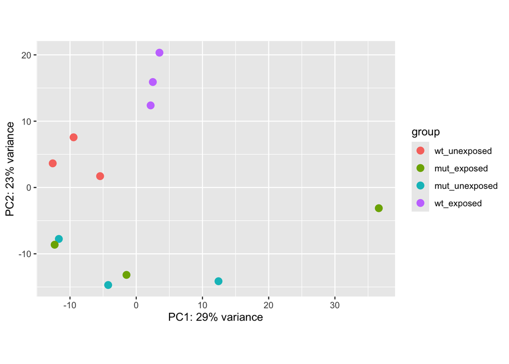

```r
## Plot visualise the PCA
plotPCA(vsd, intgroup="Group")
```

```
## using ntop=500 top features by variance
```

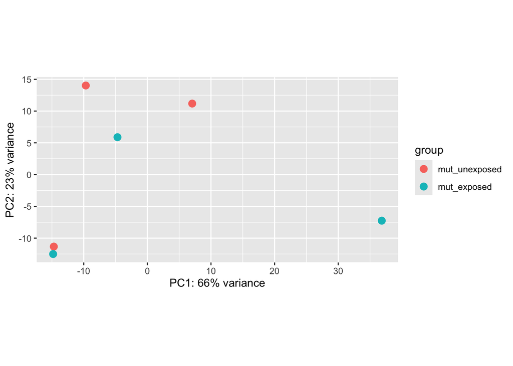

```r
plotPCA(vsdmut, intgroup = 'Group')
```

```
## using ntop=500 top features by variance
```

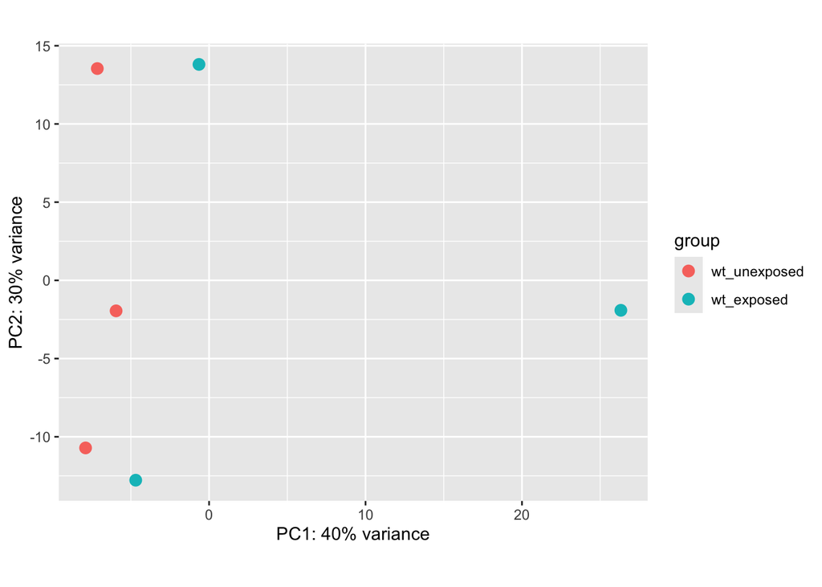

```r
plotPCA(vsdwt, intgroup = 'Group')
```

```r
## Normalise the count data
all_norm_data <- normalisation_func(dds)
mut_exposed <- normalisation_func(dds_mut)
wt_exposed <- normalisation_func(dds_wt)
```

```r
## calculate the principle component analysis
pca_mut <- principle_component(dds_mut)
pca_wt <- principle_component(dds_wt)
pca_all <- principle_component(dds)
```

```r
# Create a data frame that can used going forward from here on
count_mut_df <- cbind(mut,pca_mut$x)
count_wt_df <- cbind(wt, pca_wt$x)
count_all <- cbind(samples, pca_all$x)
```

```r
mut_only <- count_all[rownames(mut),]
wt_only <- count_all[rownames(wt),]
```

[figure not shown]

```r
## Visualise the data here
ggplot(data = mut_only) +
  geom_point(aes(x=PC7, y=PC8, colour = Group), size=5) +
  theme_minimal() +
  labs(x = 'PC1: 29% variance',
       y = 'PC2: 23% varience') +
  theme(
    axis.text = element_text(size = 20),
    axis.text.x = element_text(angle = 90, vjust = 0.5),
    axis.title.x = element_text(size = 15, vjust = 0.5),
    axis.text.y = element_text(angle = 90, vjust = 0.5),
    axis.title.y = element_text(size = 15, vjust = 0.5)
  )
```

```r
res <- results(dds)
ress_mut <- results(dds_mut)
res_wt <- results(dds_wt)
```

```r
resultsNames(dds)
```

```
## [1] "Intercept"                           "Group_mut_exposed_vs_wt_unexposed"
## [3] "Group_mut_unexposed_vs_wt_unexposed" "Group_wt_exposed_vs_wt_unexposed"
```

```r
resultsNames(dds_mut)
```

```
## [1] "Intercept"                          "Group_mut_exposed_vs_mut_unexposed"
```

```r
resultsNames(dds_wt)
```

```
## [1] "Intercept"                        "Group_wt_exposed_vs_wt_unexposed"
```